# 第04章 逻辑回归模型

## 4.1 逻辑回归模型的算法原理

### 4.1.1 逻辑回归的数学原理

回归二字源于其算法原理同样涉及线性回归模型中的线性回归方程

$$ y = k_0 + k_1x_1 + k_2x_2 + \cdots $$

上式用于预测连续变量, 取值范围为$(-\infty, + \infty)$, 而预测分类的概率的取值范围为 $(0,1)$, 所以使用Sigmoid函数将取值范围转化为 $(0,1)$

$$ f(y) = \frac{1}{1 + e^{-y}} $$

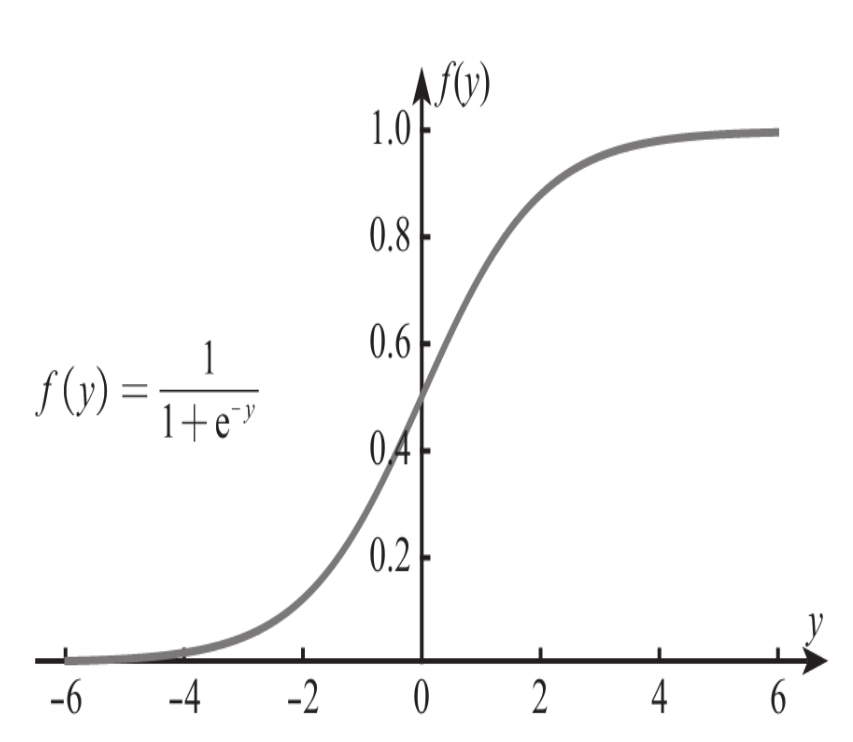

本质就是将线性回归模型进行非线性转换, 得到一个介于 $0 \sim 1$ 之间的概率值, 对于二分类问题, 其预测分类为1的概率为

$$ P = \frac{1}{1 + e^{-(k_0 + k_1x_1 + k_2x_2 + \cdots) }} $$

如果预测分类为1的概率大于0.5, 样本的预测输出就为1

### 4.1.2 逻辑回归模型的代码实现

```python
import warnings

warnings.filterwarnings('ignore')
```

```python
# 构造数据
X = [[1, 0], [5, 1], [6, 4], [4, 2], [3, 2]]
y = [0, 1, 1, 0, 0]

# 模型训练
from sklearn.linear_model import LogisticRegression # type: ignore
model = LogisticRegression()
model.fit(X, y)  # 如果运行时下面出现FutureWarning警告，不要在意，它只是在告诉你以后模型的官方默认参数会有所调整而已，不是报错
```

```
LogisticRegression()
```

```python
# 模型预测 - 预测单个数据
print(model.predict([[2,2]]))
```

```
[0]
```

```python
# 模型预测 - 预测多个数据1
print(model.predict([[1,1], [2,2], [5, 5]]))

# 模型预测 - 预测多个数据2
print(model.predict([[1, 0], [5, 1], [6, 4], [4, 2], [3, 2]]))  # 因为这里演示的多个数据和X是一样的，所以也可以直接写成model.predict(X)
```

```
[0 0 1]
[0 1 1 0 0]
```

### 4.1.3 逻辑回归模型的深入理解

逻辑回归模型的本质是预测概率, 而不是直接预测具体的类别

```python
# 预测概率：左列是分类为0的概率，右列是分类为1的概率
y_pred_proba = model.predict_proba(X)
y_pred_proba  # 直接打印
```

```
array([[0.97345945, 0.02654055],
       [0.39075704, 0.60924296],
       [0.1798892 , 0.8201108 ],
       [0.63170618, 0.36829382],
       [0.82426878, 0.17573122]])
```

```python
# 另外一种打印概率的方式：通过DataFrame展示，更加好看些
import pandas as pd # type: ignore
a = pd.DataFrame(y_pred_proba, columns=['分类为0的概率', '分类为1的概率'])  # 2.2.1 通过numpy数组创建DataFrame
a
```

|  | 分类为0的概率 | 分类为1的概率 |
| --- | --- | --- |
| 0 | 0.973459 | 0.026541 |
| 1 | 0.390757 | 0.609243 |
| 2 | 0.179889 | 0.820111 |
| 3 | 0.631706 | 0.368294 |
| 4 | 0.824269 | 0.175731 |

```python
# 打印系数和截距项
print(model.coef_)  # 系数k1与k2
print(model.intercept_)  # 截距项k0

model.coef_.T
```

```
[[1.00599764 0.02232318]]
[-4.60818025]
```

```
array([[1.00599764],
       [0.02232318]])
```

### 补充知识点: 用逻辑回归模型处理多分类问题

```python
# 构造数据，此时y有多个分类
X = [[1, 0], [5, 1], [6, 4], [4, 2], [3, 2]]
y = [-1, 0, 1, 1, 1]  # 这里有三个分类-1、0、1

# 模型训练
from sklearn.linear_model import LogisticRegression # type: ignore
model = LogisticRegression()
model.fit(X, y)  # 如果运行时下面出现FutureWarning警告，不要在意，它只是在告诉你以后模型的官方默认参数会有所调整而已，不是报错
```

```
LogisticRegression()
```

```python
print(model.predict([[0, 0]]))
```

```
[-1]
```

```python
print(model.predict_proba([[0, 0]]))
```

```
[[0.88354196 0.02339895 0.09305909]]
```

## 4.2 案例实战: 客户流失预警模型

```python
# 1.读取数据
import pandas as pd # type: ignore
df = pd.read_excel('股票客户流失.xlsx')
df.head()
```

|  | 账户资金（元） | 最后一次交易距今时间（天） | 上月交易佣金（元） | 累计交易佣金（元） | 本券商使用时长（年） | 是否流失 |
| --- | --- | --- | --- | --- | --- | --- |
| 0 | 22686.5 | 297 | 149.25 | 2029.85 | 0 | 0 |
| 1 | 190055.0 | 42 | 284.75 | 3889.50 | 2 | 0 |
| 2 | 29733.5 | 233 | 269.25 | 2108.15 | 0 | 1 |
| 3 | 185667.5 | 44 | 211.50 | 3840.75 | 3 | 0 |
| 4 | 33648.5 | 213 | 353.50 | 2151.65 | 0 | 1 |

```python
# 2.划分特征变量和目标变量
X = df.drop(columns='是否流失')
y = df['是否流失']
```

```python
# 3.划分训练集和测试集
from sklearn.model_selection import train_test_split
X_train, X_test, y_train, y_test = train_test_split(X, y, test_size=0.2, random_state=1)  # 设置random_state使得每次划分的数据一样

X_train.head()
```

|  | 账户资金（元） | 最后一次交易距今时间（天） | 上月交易佣金（元） | 累计交易佣金（元） | 本券商使用时长（年） |
| --- | --- | --- | --- | --- | --- |
| 1814 | 43251.5 | 192 | 98.50 | 2258.35 | 0 |
| 5946 | 304449.5 | 22 | 369.50 | 5160.55 | 3 |
| 3881 | 441357.5 | 9 | 325.75 | 6681.75 | 5 |
| 2389 | 587076.5 | 2 | 427.25 | 8300.85 | 5 |
| 3676 | 204027.5 | 39 | 352.00 | 4044.75 | 2 |

```python
# 4.模型搭建
from sklearn.linear_model import LogisticRegression
model = LogisticRegression()
model.fit(X_train, y_train)
```

```
LogisticRegression()
```

```python
# 5.模型使用1 - 预测数据结果
y_pred = model.predict(X_test)
print(y_pred[0:100])  # 打印预测内容的前100个看看
```

```
[0 0 0 0 0 0 0 1 0 0 0 0 1 0 0 0 0 0 0 0 0 0 0 0 0 0 0 0 0 0 0 0 0 0 0 0 0
 0 0 0 0 0 1 1 1 0 0 1 0 1 0 0 0 0 1 0 0 0 0 0 0 0 1 1 0 0 0 1 0 0 0 0 0 0
 0 0 0 0 0 0 0 1 0 0 0 0 0 0 0 0 1 1 0 0 0 1 0 0 0 1]
```

```python
# 放到一个DataFrame里进行查看比对
a = pd.DataFrame()  # 创建一个空DataFrame
a['预测值'] = list(y_pred)
a['实际值'] = list(y_test)
a.head()  # 可以看到此时前5个预测准确度为80%
```

|  | 预测值 | 实际值 |
| --- | --- | --- |
| 0 | 0 | 0 |
| 1 | 0 | 0 |
| 2 | 0 | 0 |
| 3 | 0 | 1 |
| 4 | 0 | 0 |

```python
# 查看全部的预测准确度
from sklearn.metrics import accuracy_score
score = accuracy_score(y_pred, y_test)
print(score)

# 另外一种查看模型预测准确度的方法
model.score(X_test, y_test)
```

```
0.7977288857345636
```

```
0.7977288857345636
```

```python
# 6.模型使用2 - 预测概率
y_pred_proba = model.predict_proba(X_test)
y_pred_proba[0:5]
```

```
array([[0.82041509, 0.17958491],
       [0.84029656, 0.15970344],
       [0.7981937 , 0.2018063 ],
       [0.62989223, 0.37010777],
       [0.61636604, 0.38363396]])
```

```python
# 另一种查看概率的方式
a = pd.DataFrame(y_pred_proba, columns=['不流失概率', '流失概率'])
a.head()
```

|  | 不流失概率 | 流失概率 |
| --- | --- | --- |
| 0 | 0.820415 | 0.179585 |
| 1 | 0.840297 | 0.159703 |
| 2 | 0.798194 | 0.201806 |
| 3 | 0.629892 | 0.370108 |
| 4 | 0.616366 | 0.383634 |

```python
# 7.查看各个特征变量的系数
model.coef_
```

```
array([[ 2.41952552e-05,  8.16880529e-03,  1.04321146e-02,
        -2.54894683e-03, -1.10120675e-04]])
```

## 4.3 模型评估方法: ROC曲线与KS曲线

二分类模型的主流评估方法有ROC曲线和KS曲线两种

ROC曲线

- 命中率与假报警率(横轴)的曲线

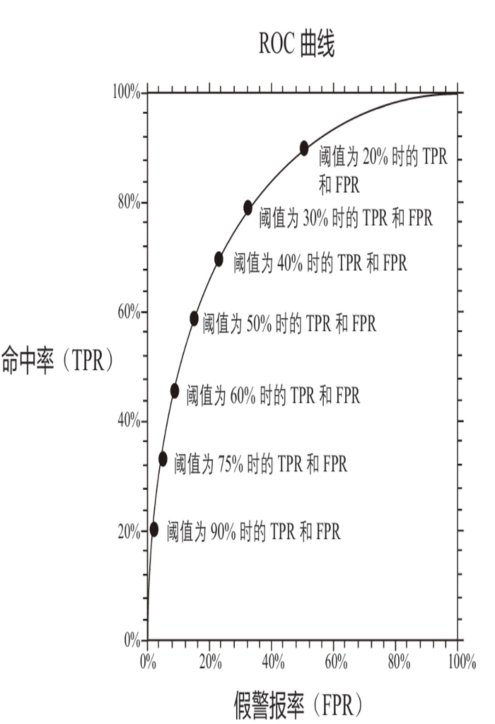

- 命中率与假报警率

如果把假报警率理解为代价, 那么命中率就是收益, 所以可以说在阈值相同的情况下, 希望假报警率尽可能小, 命中率尽可能高, 反映在图形上就是ROC曲线尽可能地陡峭

- 其他指标

#### 混淆矩阵的Python代码实现

```python
from sklearn.metrics import confusion_matrix
m = confusion_matrix(y_test, y_pred)  # 传入预测值和真实值
print(m)
```

```
[[968  93]
 [192 156]]
```

```python
a = pd.DataFrame(m, index=['0（实际不流失）', '1（实际流失）'], columns=['0（预测不流失）', '1（预测流失）'])
a
```

|  | 0（预测不流失） | 1（预测流失） |
| --- | --- | --- |
| 0（实际不流失） | 968 | 93 |
| 1（实际流失） | 192 | 156 |

```python
from sklearn.metrics import classification_report
print(classification_report(y_test, y_pred))  # 传入预测值和真实值
```

```
              precision    recall  f1-score   support

           0       0.83      0.91      0.87      1061
           1       0.63      0.45      0.52       348

    accuracy                           0.80      1409
   macro avg       0.73      0.68      0.70      1409
weighted avg       0.78      0.80      0.79      1409
```

### 4.3.2 案例实战: 用ROC曲线评估客户流失预警模型

```python
y_pred_proba[:,1]
```

```
array([0.17958491, 0.15970344, 0.2018063 , ..., 0.04220526, 0.09782415,
       0.63586812])
```

```python
# 1.计算ROC曲线需要的假警报率（fpr）、命中率（tpr）及阈值（thres）
from sklearn.metrics import roc_curve
fpr, tpr, thres = roc_curve(y_test, y_pred_proba[:,1])
```

```python
# 2.查看假警报率（fpr）、命中率（tpr）及阈值（thres）
a = pd.DataFrame()  # 创建一个空DataFrame
a['阈值'] = list(thres)
a['假警报率'] = list(fpr)
a['命中率'] = list(tpr)
a.head()
```

|  | 阈值 | 假警报率 | 命中率 |
| --- | --- | --- | --- |
| 0 | inf | 0.000000 | 0.000000 |
| 1 | 0.930369 | 0.000000 | 0.002874 |
| 2 | 0.867342 | 0.000000 | 0.034483 |
| 3 | 0.864187 | 0.001885 | 0.034483 |
| 4 | 0.857304 | 0.001885 | 0.040230 |

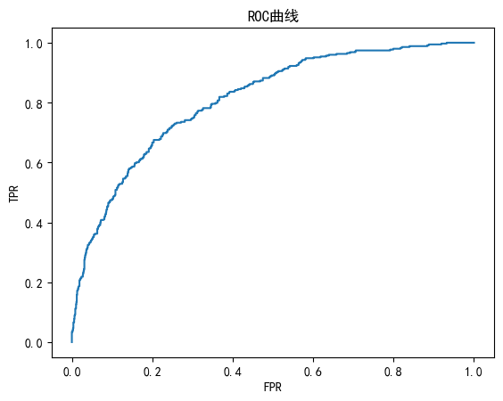

```python
# 3.绘制ROC曲线
import matplotlib.pyplot as plt
plt.rcParams['font.sans-serif'] = ['SimHei']  # 设置中文
plt.plot(fpr, tpr)  # 通过plot()函数绘制折线图
plt.title('ROC曲线')  # 添加标题，注意如果要写中文，需要在之前添加一行代码：plt.rcParams['font.sans-serif'] = ['SimHei']
plt.xlabel('FPR')  # 添加X轴标签
plt.ylabel('TPR')  # 添加Y轴标
plt.show()
```

```python
# 4.求出模型的AUC值
from sklearn.metrics import roc_auc_score
score = roc_auc_score(y_test, y_pred_proba[:,1])
score
```

```
np.float64(0.8103854528908967)
```

该面积的取值范围通常为0.5~1, 0.5表示随机判断, 1则代表完美的模型, 在商业实战中, AUC值能达到0.75以上就已经可以接受, 能达到0.85就是非常不错的模型

### 4.3.3 KS曲线的基本原理

将命中率与假报警率之差作为纵坐标, 阈值作为横坐标

```python
from sklearn.metrics import roc_curve
fpr, tpr, thres = roc_curve(y_test, y_pred_proba[:,1])
```

```python
a = pd.DataFrame()  # 创建一个空DataFrame
a['阈值'] = list(thres)
a['假警报率'] = list(fpr)
a['命中率'] = list(tpr)
a.head()
```

|  | 阈值 | 假警报率 | 命中率 |
| --- | --- | --- | --- |
| 0 | inf | 0.000000 | 0.000000 |
| 1 | 0.930369 | 0.000000 | 0.002874 |
| 2 | 0.867342 | 0.000000 | 0.034483 |
| 3 | 0.864187 | 0.001885 | 0.034483 |
| 4 | 0.857304 | 0.001885 | 0.040230 |

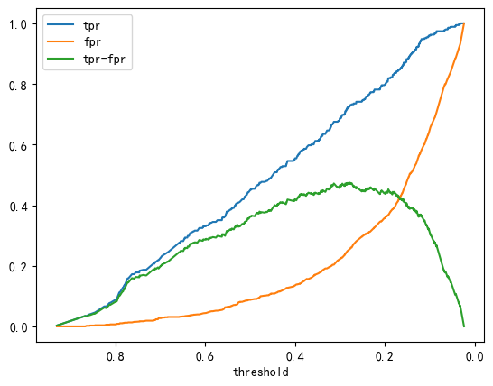

```python
plt.plot(thres[1:], tpr[1:])
plt.plot(thres[1:], fpr[1:])
plt.plot(thres[1:], tpr[1:] - fpr[1:])
plt.xlabel('threshold')
plt.legend(['tpr', 'fpr', 'tpr-fpr'])
plt.gca().invert_xaxis()
plt.show()
```

```python
max(tpr - fpr)
```

```
np.float64(0.4744656418256471)
```

```python
# KS值对应的阈值
a['TPR-FPR'] = a['命中率'] - a['假警报率']
print(a.head())
```

```
         阈值      假警报率       命中率   TPR-FPR
0       inf  0.000000  0.000000  0.000000
1  0.930369  0.000000  0.002874  0.002874
2  0.867342  0.000000  0.034483  0.034483
3  0.864187  0.001885  0.034483  0.032598
4  0.857304  0.001885  0.040230  0.038345
```

```python
# 获取KS值对应的阈值等信息
print(a[a['TPR-FPR'] == max(a['TPR-FPR'])])
```

```
          阈值      假警报率       命中率   TPR-FPR
224  0.27769  0.255419  0.729885  0.474466
```